# Working with RStudio and Git

Heath O’Brien

12 January, 2016

## What is Git

- A version control system that saves a snapshot of your project every time you make changes
- Each change has to be documented with a description of the changes
- If multiple people are working on the same project (or if one person works on it in multiple places), changes can be synced
- Syncing requires storing the project on a Git server (eg, [GitHub](https://github.com/))
- Since code is stored online, it’s easy to share with others
- GitHub is a free service, but requires that all code to be publicly available
  - this isn’t normally a problem for biologists, though you may want to ensure that your **data** are not included in the repository

## The preferred workflow for Git

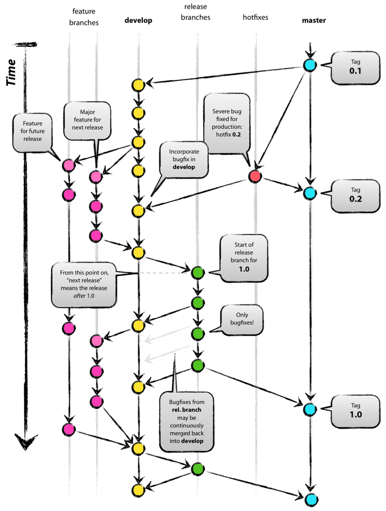

## Setup

- Installing RStudio
  - Available from https://www.rstudio.com
  - Appears to require EUR to install
- Installing GitHub Desktop
  - Available from https://desktop.github.com
  - For some reason, this seems to install with no difficulty
  - Create GitHub account and log into GitHub Desktop using these credentials
  - In theory, it is possible to run Git directly through RStudio, but:
    1. You would have to learn a new interface to use Git for any other project
    2. I can’t get it to work with the networked drive
- Cloning [LearningMLwiN](https://github.com/MixedModels/LearningMLwinN)
  - Click on + in upper left corner of GitHub Desktop, then “Clone”
  - Select MixedModels/LearningMLwinN from the menu (if it doesn’t show up, ask me to add you to MixedModels)
  - Select destination folder
  - Open RStudio, click on project selector in upper right corner, and select “New Project”
  - Click on “Existing Directory” and navigate to cloned repository, then click “select folder” and “Create Project”
- Adding an Existing Project
  - Click on project selector in upper right corner of RStudio and select “New Project”
  - Click on “Existing Directory” and navigate to folder, then click “Select Folder” and “Create Project”
  - Click on + in upper left corner of GitHub Desktop, then “Create”
  - Navigate to folder and click OK
  - Give repository a name and create (note that redundant names in different locations on your file system will clash on the server)
- Starting from Scratch
  - Click on project selector in upper right corner of RStudio and select “New Project”
  - Click on “New Directory”, then “Empty Project”, then pick a project name and location
  - Click on + in upper left corner of GitHub Desktop, then “Create”
  - Navigate to folder and click OK
  - Give repository a name and create

## Working with RStudio

- Collects all of the files associated with a project together
- Snippets of code from a script can be run on their own, or code can be entered directly into the console
- Nice GUIs for viewing and saving plots, importing data-sets, and viewing data-frames
- Work-spaces are automatically saved for each project
- I have not figured out an easy way to work on scripts that accept command line arguments

## R Markdown

- Used to prepare this document
- Simple plain text [syntax](https://www.rstudio.com/wp-content/uploads/2015/02/rmarkdown-cheatsheet.pdf) used to format document (this syntax is also used many other places, including GitHub)
- Code and output can be embedded:

```r
library(lme4) #glmer
library(readr)
SchoolData<-read_tsv("https://raw.githubusercontent.com/MixedModels/LearningMLwinN/master/tutorial.txt")
SchoolData$school<-factor(SchoolData$school)
SchoolData$girl<-factor(SchoolData$girl)
MOD.1 <- lmer(normexam ~ standlrt + (1|school), data = SchoolData, REML=F)
summary(MOD.1)
```

```
## Linear mixed model fit by maximum likelihood  ['lmerMod']
## Formula: normexam ~ standlrt + (1 | school)
##    Data: SchoolData
##
##      AIC      BIC   logLik deviance df.resid
##   9366.7   9391.9  -4679.4   9358.7     4055
##
## Scaled residuals:
##     Min      1Q  Median      3Q     Max
## -3.7192 -0.6290  0.0266  0.6850  3.2723
##
## Random effects:
##  Groups   Name        Variance Std.Dev.
##  school   (Intercept) 0.09217  0.3036
##  Residual             0.56594  0.7523
## Number of obs: 4059, groups:  school, 65
##
## Fixed effects:
##             Estimate Std. Error t value
## (Intercept) 0.001539   0.040031    0.04
## standlrt    0.563440   0.012469   45.19
##
## Correlation of Fixed Effects:
##          (Intr)
## standlrt 0.008
```

- Plots can also be embedded without displaying the code:

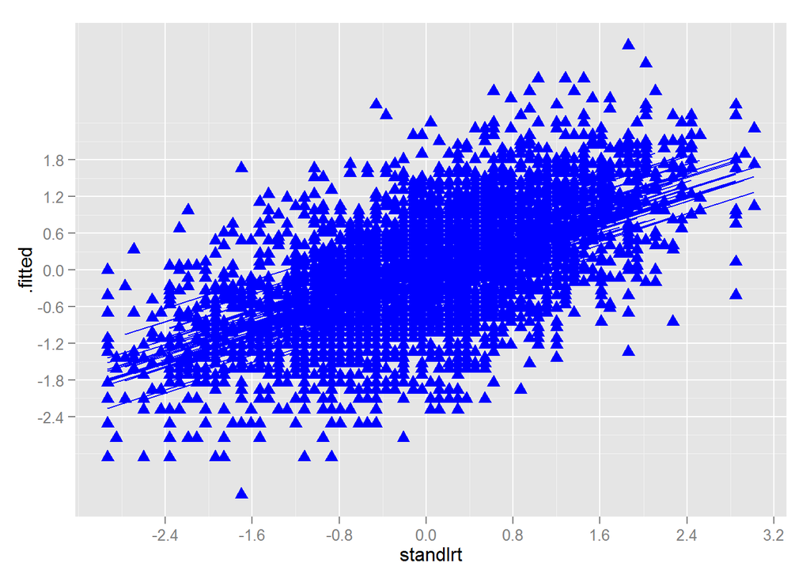

- Reports can be converted to html, pdf, ms word, etc using the “Knit” drop-down menu
- A workflow that I have found to be useful is to experiment with analyses using R Markdown (which can be easily shared with collaborators and mentors), then to prepare R scripts that generate all of the final analyses included in the paper

## Working with GitHub Desktop

- To make changes to the repo:
  - Click on “Changes” at top of window
  - Select files to add
  - Write summary of changes and (optional) description
  - Click “commit to master”
- To revert changes:
  - Click on “History” at top of window
  - Navigate through commits to find the offending edit (deletions are marked red, additions are green)
  - Click on “Revert”
- To sync local copy to remote server:
  - Click “Sync”
- To resolve conflicts:
  - If sync fails because changes on remote server can’t be automatically merged with local changes, open file in RStudio and edit conflicts manually
  - Conflicts look like this:

  - ```
    <<<<<<<<<<<< HEAD
    local version of code
    =============
    remote version
    >>>>>>>>>>>> origin/master
    ```

  - Edit file to include whatever parts from the local and remote versions you please (and remove markers added by Git)
  - Return to GitHub Desktop, commit changes, and redo sync
  - If all else fails, save local files in another location, delete the project, clone fresh copy from server, then add back in your local changes
- Working with branches:
  - I generally don’t bother creating additional branches beyond the local and remote master versions
  - I mostly mention it because it is a central feature of git and there is a prominant widget for it in GitHub Desktop
  - If multiple people are working on the same project, it’s nice if they can work on the same files independently without having to merge everything together each time they make a commit
  - This can acomplished by creating seperate branches for each person, then merging everything together once everyone has completed their part of the project
  - Create a new branch by clicking on the “Create new branch” is in the upper left, next to the “master” dropdown menu
  - Give your branch a name and click OK
  - Any changes made in RStudio will now be confined to your new branch
  - The “Sync” button will now be replaced by a “Publish” button because there is no copy of your new branch on the server to sync to
  - After clicking on “Publish”, the “Sync” button will come back and any changes made to your files will not conflict with changes on the master version on the server
  - You can now use the drop down menu in the upper left to switch between brances, which will automatically change the code in RStudio
  - When you are ready to merge branches back together, you need to make a Pull request, then go to the online version and confirm the request
  - There is a Pull request button in GitHub Desktop, but it’s probably easier to do it all online
  - If there are conflicts, they can be resolved as above

## A few additional considerations

- Bookmarking snapshots (example: the version used for the analyses in a paper submission)
  - Make zipped copy of directory
  - Make a note the number of the last commit before submission (eg; ce289b3)
  - Create a separate branch for each submission
  - Tag commit
    - Go online and click on the “0 releases” button beneath the project description
    - Click on “Create a new release”
    - Give release a name (unfortunately only names like “v1.0” are supported)
    - Click on “This is a pre-release” if it’s not the final version of the paper, then on “Publish release”
    - This will automatically create a ziped version of all the code that can be navigated to by clicking on the “1 release” button for the project
- Excluding private files
  - When you initialise a repo, a .gitignore file will automatically be created with a list of files that will never be synced to the server
  - Files on the list will not show up on the lists of modified files to add to a commit
  - It’s a good idea to list any data files that you don’t want to make public in this file, along with any config files that contain things like login credentials
  - Of course, any files that are not part of the repo will need to be synced some other way
- README, LICENSE
  - When a repo is created online, you have the option of creating a README.md file that is displayed automatically on the landing page for your project
  - If you are creating a repo locally, you’d need to do this manually with RStudio (or other text editor)
  - You are also given the option of adding a license to the repo, though the available options are tailored to software (I would suggest using the Creative Commons [CC-BY](https://creativecommons.org/licenses/by/2.0/uk/legalcode) license for most biology projects)

## Beyond R

- Using [pandoc](http://pandoc.org/) directly to format Markdown files
  - Reports, letters, manuscripts
  - Requires a some knowledge of LaTeX for any advanced formatting
  - This command:

```
pandoc -r markdown  -s -S --latex-engine=pdflatex --template=letter.template -o letter.pdf letter.md
```

can convert this:

```
---
address:
 - Senior Scientific Editor
 - Nature
opening: Dear Sir,
closing: Yours sincerely

...


**RE: Manuscript submission.**

I write to ask you to consider for publication in your august journal our attached manuscript entitled: “Genome editing and precision medicine: a systems biology approach” by Heath O'Brien and co-authors.

In this landmark study will revolutionize our understanding of medicine and something about CRISPR. You would be a fool to pass up an opportunity to publish it.

When you do send decide to send it to reviewers, I suggest the following junior colleagues who would be too intimidated to criticize it, even anonymously: [...]

Thank you for your consideration.
```

into this:

[figure not shown]

- Meta-notebooks
  - Notes can be organised in a logical order, without interleaving unrelated work that was done on the same day
  - Commit history preserves a chronological record
  - Additional explanation, comments, etc can be recorded in commit message without cluttering notes
  - If you’re fortunate enough to have lab mentors, they can easily review your notes and leave comments
  - If using the free version of GitHub, you may need to be a bit coy about exactly what you are working on to prevent your competetors from stealing you work
- Using Git for manuscript writing
  - Can be used to avoid this:

[figure not shown]

  - Merging changes by different co-authors is done automatically
  - Keeps a record of all changes, who made them, and why
  - Discussions about particular changes can be had in the comment thread for that change instead of in email threads
  - Issue tracker can be used as a to-do list, and also includes comment threads for discussion of proposed tasks
  - Branching can be used to allow a co-author to make a series of commits that can all be merged at once
  - This may well be something you’d want a private repo for. Private GitHub accounts are £5 per month, but appear to be available for free to educational institutions

Working with RStudio and Git by Heath O’Brien is licensed under a [Creative Commons Attribution 4.0 International License](http://creativecommons.org/licenses/by/4.0/).